# Aprendizado de máquina: Trabalho Final 1

Lyncoln Sousa

# Objetivo

- O objetivo do trabalho é utilizar técnicas de aprendizado de máquina na base de dados fornecida sobre NBA para classificar possíveis promissores atletas.

# Variáveis

| Var_name | Description |
| --- | --- |
| Name | Name |
| GP | Games Played |
| MIN | Minutes Played |
| PTS | PointsPerGame |
| FGM | FieldGoalsMade |
| FGA | FieldGoalsAttemps |
| FG% | FieldGoalPercent |
| 3P MADE | 3PointMade |
| 3PA | 3PointAttemps |
| 3P% | 3PointesPercent |
| FTM | FreeThrowMade |
| FTA | FreeThrowAttempts |
| FT% | FreeThrowPercent |
| OREB | OffensiveRebounds |
| DREB | DefensiveRebounds |
| REB | Rebounds |
| AST | Assists |
| SLT | Steals |
| BLK | Blocks |
| TOV | Turnovers |
| TARGET_5Yrs | Outcome: 1 if carrer length > 5yrs, 0 else |

- Em geral, a base de dados possui informações sobre jovens atletas que conseguiram chegar, ou não, a 5 anos jogados na NBA. O empresário afirma que se o indivíduo jogou 5 anos na NBA, ele é talentoso.
- A base de dados fornecida apresenta 1350 observações e 21 variáveis, 19 são quantitativas enquanto 2 são qualitativas.

# Metodologia

- Foi gerado algumas medidas descritivas da base de dados, tais como: minimo, máximo, medidas de posição e quantidade de dados faltantes por variáveis.
- O modelo GBM (Gradient Boosting Machine) foi utilizado para realizar as classificações. Esse é um modelo que utiliza árvores de decisão para criação de um classificador ou regressor.

## Pré Processamento

- Foi observado existência de dados faltantes, para isso foi utilizado o método de imputação KNN com k=5, assim, cada dado faltante será preenchido com a média de seus 5 vizinhos mais próximos.
- Também foi verificado a existência de variáveis com variância 0 ou quase 0 (nzv), pois variáveis assim não acrescentam informação para modelagem. Nenhuma das variáveis analisadas foram classificadas como nzv.
- Foram realizados cálculos para determinar as correlações entre as variáveis, as que obtiveram maior que 85% foram descartadas pois podem prejudicar a modelagem. Dentre todas as 21, foram excluídas 6, elas são: PTS, MIN, FGM, FTM, REB, X3P_MADE.
- Também foi verificado a existência de dependência linear entre as variáveis, isso é, se uma variável é combinação linear de uma outra. Não foi encontrado dependência linear.

## Validação Cruzado

- Com os dados tratados, foi realizado a modelagem de GBM com os seguinte hiperparâmetro:
- Profundidade = 1,2,3,5,8
- Número de árvores = 500,1000,1500,2500
- Coeficiente de aprendizado = 0.01,0.02,0.03
- Para a realização de reamostragem, foram escolhidos os métodos de bootstrap com 10 reamotragens e kfold repetido com 10 reamostragens e 3 repetições. O objetivo é verificar qual é o melhor método.
- O desempenho de cada modelo será analisado baseado no resultado do seu AUC.
- Dentre os 120 modelos testados, aquele com melhor desempenho será escolhido para a realização da modelagem final.

# Resultados

## Tabela de medidas descritivas

|  | gp | min | pts | fgm | fga | fg | x3p_made | x3pa | x3p | ftm | fta | ft | oreb | dreb | reb | ast | stl | blk | tov |
| --- | --- | --- | --- | --- | --- | --- | --- | --- | --- | --- | --- | --- | --- | --- | --- | --- | --- | --- | --- |
| Min. | 11.0 | 3.1 | 0.70 | 0.30 | 0.80 | 23.8 | 0.000 | 0.000 | 0.0 | 0.0 | 0.00 | 0.0 | 0.00 | 0.20 | 0.30 | 0.00 | 0.000 | 0.000 | 0.10 |
| 1st Qu. | 47.0 | 10.9 | 3.70 | 1.40 | 3.30 | 40.2 | 0.000 | 0.000 | 0.0 | 0.6 | 0.90 | 64.7 | 0.40 | 1.00 | 1.50 | 0.60 | 0.300 | 0.100 | 0.70 |
| Median | 63.0 | 16.1 | 5.55 | 2.10 | 4.80 | 44.1 | 0.100 | 0.300 | 22.4 | 1.0 | 1.50 | 71.2 | 0.80 | 1.70 | 2.50 | 1.10 | 0.500 | 0.200 | 1.00 |
| Mean | 60.4 | 17.6 | 6.80 | 2.63 | 5.89 | 44.2 | 0.248 | 0.779 | 19.3 | 1.3 | 1.82 | 70.3 | 1.01 | 2.03 | 3.03 | 1.55 | 0.619 | 0.369 | 1.19 |
| 3rd Qu. | 77.0 | 22.9 | 8.80 | 3.40 | 7.50 | 47.9 | 0.400 | 1.200 | 32.5 | 1.6 | 2.30 | 77.6 | 1.40 | 2.60 | 4.00 | 2.00 | 0.800 | 0.500 | 1.50 |
| Max. | 82.0 | 40.9 | 28.20 | 10.20 | 19.80 | 73.7 | 2.300 | 6.500 | 100.0 | 7.7 | 10.20 | 100.0 | 5.30 | 9.60 | 13.90 | 10.60 | 2.500 | 3.900 | 4.40 |
| NA | 0.0 | 0.0 | 0.00 | 0.00 | 0.00 | 0.0 | 0.000 | 0.000 | 11.0 | 0.0 | 0.00 | 0.0 | 0.00 | 0.00 | 0.00 | 0.00 | 0.000 | 0.000 | 0.00 |

## Proporção de classificação

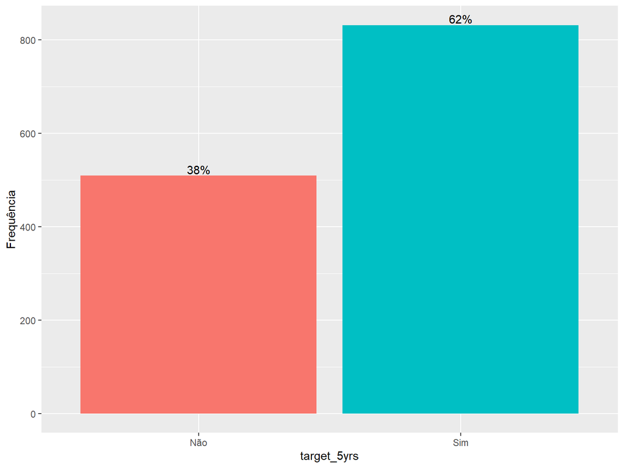

## Modelagem por Bootstrap

| shrinkage | interaction.depth | n.minobsinnode | n.trees | ROC | Sens | Spec | ROCSD | SensSD | SpecSD |
| --- | --- | --- | --- | --- | --- | --- | --- | --- | --- |
| 0.02 | 1 | 10 | 500 | 0.7360742 | 0.4897487 | 0.8083469 | 0.0179425 | 0.0582529 | 0.0309960 |
| 0.01 | 1 | 10 | 1000 | 0.7356544 | 0.4928804 | 0.8073086 | 0.0182685 | 0.0564141 | 0.0300270 |
| 0.01 | 1 | 10 | 500 | 0.7355423 | 0.4700280 | 0.8139597 | 0.0190183 | 0.0573608 | 0.0339551 |
| 0.03 | 1 | 10 | 500 | 0.7349641 | 0.5011345 | 0.8016327 | 0.0180686 | 0.0541201 | 0.0303905 |
| 0.01 | 1 | 10 | 1500 | 0.7344759 | 0.4969571 | 0.7979237 | 0.0185185 | 0.0586054 | 0.0331156 |
| 0.01 | 2 | 10 | 500 | 0.7331509 | 0.5005241 | 0.7976356 | 0.0177648 | 0.0453508 | 0.0322626 |
| 0.02 | 1 | 10 | 1000 | 0.7330140 | 0.5029127 | 0.7979219 | 0.0189153 | 0.0556718 | 0.0321356 |
| 0.01 | 3 | 10 | 500 | 0.7311117 | 0.5082253 | 0.7926226 | 0.0183844 | 0.0439509 | 0.0316149 |
| 0.01 | 1 | 10 | 2500 | 0.7301538 | 0.4999779 | 0.7926617 | 0.0191687 | 0.0605348 | 0.0301202 |
| 0.01 | 2 | 10 | 1000 | 0.7299312 | 0.5083512 | 0.7917321 | 0.0188368 | 0.0448367 | 0.0321288 |
| 0.02 | 2 | 10 | 500 | 0.7293964 | 0.5122322 | 0.7894025 | 0.0186412 | 0.0433278 | 0.0329799 |
| 0.02 | 1 | 10 | 1500 | 0.7279637 | 0.4950320 | 0.7937183 | 0.0198608 | 0.0496167 | 0.0260282 |
| 0.03 | 1 | 10 | 1000 | 0.7277687 | 0.4992030 | 0.7963155 | 0.0197205 | 0.0516384 | 0.0274936 |
| 0.01 | 5 | 10 | 500 | 0.7272565 | 0.5147278 | 0.7859639 | 0.0179933 | 0.0474704 | 0.0259954 |
| 0.01 | 3 | 10 | 1000 | 0.7251597 | 0.5100525 | 0.7864710 | 0.0193393 | 0.0539158 | 0.0301516 |
| 0.01 | 2 | 10 | 1500 | 0.7251053 | 0.5131384 | 0.7869305 | 0.0199796 | 0.0473367 | 0.0303223 |
| 0.02 | 3 | 10 | 500 | 0.7245121 | 0.5067317 | 0.7899732 | 0.0194429 | 0.0493174 | 0.0252395 |
| 0.03 | 2 | 10 | 500 | 0.7243202 | 0.5060779 | 0.7860149 | 0.0207271 | 0.0460594 | 0.0315112 |
| 0.01 | 8 | 10 | 500 | 0.7226923 | 0.5081205 | 0.7821003 | 0.0196119 | 0.0454196 | 0.0311844 |
| 0.03 | 1 | 10 | 1500 | 0.7218785 | 0.4960160 | 0.7880472 | 0.0220179 | 0.0533994 | 0.0293196 |
| 0.02 | 1 | 10 | 2500 | 0.7201910 | 0.4896248 | 0.7861146 | 0.0219138 | 0.0523156 | 0.0284319 |
| 0.02 | 2 | 10 | 1000 | 0.7193821 | 0.5020925 | 0.7834894 | 0.0225547 | 0.0439850 | 0.0292894 |
| 0.01 | 5 | 10 | 1000 | 0.7192655 | 0.5099842 | 0.7780081 | 0.0204175 | 0.0445640 | 0.0319563 |
| 0.01 | 3 | 10 | 1500 | 0.7191601 | 0.5033703 | 0.7805913 | 0.0208176 | 0.0431361 | 0.0276340 |
| 0.02 | 5 | 10 | 500 | 0.7184883 | 0.5105966 | 0.7816663 | 0.0198800 | 0.0431161 | 0.0306067 |
| 0.03 | 3 | 10 | 500 | 0.7174276 | 0.5048525 | 0.7778357 | 0.0212832 | 0.0485058 | 0.0300294 |
| 0.01 | 2 | 10 | 2500 | 0.7169132 | 0.5084536 | 0.7789435 | 0.0225573 | 0.0410410 | 0.0331793 |
| 0.02 | 3 | 10 | 1000 | 0.7143957 | 0.5002086 | 0.7759484 | 0.0223635 | 0.0387527 | 0.0281290 |
| 0.01 | 8 | 10 | 1000 | 0.7138804 | 0.5106929 | 0.7763804 | 0.0220595 | 0.0427768 | 0.0310796 |
| 0.02 | 8 | 10 | 500 | 0.7130063 | 0.5064052 | 0.7739516 | 0.0223198 | 0.0364143 | 0.0348829 |
| 0.01 | 5 | 10 | 1500 | 0.7126689 | 0.5020234 | 0.7720505 | 0.0220987 | 0.0444095 | 0.0331102 |
| 0.02 | 2 | 10 | 1500 | 0.7119510 | 0.4979394 | 0.7752814 | 0.0234529 | 0.0412614 | 0.0291887 |
| 0.03 | 1 | 10 | 2500 | 0.7119248 | 0.4963486 | 0.7803286 | 0.0227504 | 0.0431623 | 0.0295359 |
| 0.03 | 5 | 10 | 500 | 0.7116642 | 0.5026479 | 0.7748116 | 0.0237506 | 0.0390668 | 0.0289110 |
| 0.03 | 2 | 10 | 1000 | 0.7114905 | 0.5035530 | 0.7743201 | 0.0236885 | 0.0397068 | 0.0293350 |
| 0.01 | 3 | 10 | 2500 | 0.7101404 | 0.5038310 | 0.7677626 | 0.0233614 | 0.0397292 | 0.0325980 |
| 0.01 | 8 | 10 | 1500 | 0.7079984 | 0.5066720 | 0.7705770 | 0.0231341 | 0.0390174 | 0.0275859 |
| 0.02 | 3 | 10 | 1500 | 0.7071760 | 0.5036638 | 0.7697373 | 0.0234157 | 0.0331090 | 0.0296991 |
| 0.02 | 5 | 10 | 1000 | 0.7067007 | 0.5069247 | 0.7701199 | 0.0223313 | 0.0389517 | 0.0275941 |
| 0.03 | 8 | 10 | 500 | 0.7066977 | 0.5026453 | 0.7700079 | 0.0247594 | 0.0374400 | 0.0287080 |
| 0.03 | 3 | 10 | 1000 | 0.7045366 | 0.4999621 | 0.7667578 | 0.0238365 | 0.0449227 | 0.0313965 |
| 0.01 | 5 | 10 | 2500 | 0.7037473 | 0.5030011 | 0.7645266 | 0.0223880 | 0.0394218 | 0.0283692 |
| 0.02 | 8 | 10 | 1000 | 0.7034263 | 0.5054774 | 0.7666816 | 0.0232241 | 0.0353143 | 0.0289256 |
| 0.03 | 2 | 10 | 1500 | 0.7032714 | 0.5010556 | 0.7653333 | 0.0251377 | 0.0349856 | 0.0332431 |
| 0.02 | 2 | 10 | 2500 | 0.7014097 | 0.5046788 | 0.7619008 | 0.0247148 | 0.0381383 | 0.0351469 |
| 0.01 | 8 | 10 | 2500 | 0.7010042 | 0.5084440 | 0.7662760 | 0.0230560 | 0.0358922 | 0.0281566 |
| 0.02 | 5 | 10 | 1500 | 0.7003282 | 0.5024492 | 0.7630151 | 0.0223275 | 0.0369614 | 0.0277089 |
| 0.03 | 5 | 10 | 1000 | 0.6985622 | 0.5058317 | 0.7652230 | 0.0240174 | 0.0394722 | 0.0341042 |
| 0.02 | 8 | 10 | 1500 | 0.6979228 | 0.5004221 | 0.7672256 | 0.0230464 | 0.0330372 | 0.0295944 |
| 0.03 | 3 | 10 | 1500 | 0.6969910 | 0.5041199 | 0.7617756 | 0.0245420 | 0.0395270 | 0.0288077 |
| 0.03 | 8 | 10 | 1000 | 0.6969480 | 0.4975451 | 0.7608769 | 0.0248544 | 0.0330003 | 0.0298423 |
| 0.02 | 3 | 10 | 2500 | 0.6967910 | 0.5034913 | 0.7608263 | 0.0237159 | 0.0390597 | 0.0272231 |
| 0.03 | 8 | 10 | 1500 | 0.6932552 | 0.4965780 | 0.7597048 | 0.0240784 | 0.0339215 | 0.0314520 |
| 0.02 | 8 | 10 | 2500 | 0.6930337 | 0.5012293 | 0.7613935 | 0.0229840 | 0.0363277 | 0.0295288 |
| 0.02 | 5 | 10 | 2500 | 0.6922604 | 0.5019648 | 0.7591297 | 0.0215358 | 0.0321800 | 0.0227484 |
| 0.03 | 5 | 10 | 1500 | 0.6916441 | 0.5101733 | 0.7592013 | 0.0239707 | 0.0425045 | 0.0252537 |
| 0.03 | 8 | 10 | 2500 | 0.6911294 | 0.5033528 | 0.7607674 | 0.0223567 | 0.0326540 | 0.0313712 |
| 0.03 | 2 | 10 | 2500 | 0.6908109 | 0.5033856 | 0.7578661 | 0.0248209 | 0.0371634 | 0.0359223 |
| 0.03 | 3 | 10 | 2500 | 0.6874889 | 0.4981690 | 0.7558085 | 0.0246978 | 0.0415112 | 0.0305628 |
| 0.03 | 5 | 10 | 2500 | 0.6868319 | 0.5062804 | 0.7558685 | 0.0224858 | 0.0351066 | 0.0258190 |

## Modelagem por repeatedcv

| shrinkage | interaction.depth | n.minobsinnode | n.trees | ROC | Sens | Spec | ROCSD | SensSD | SpecSD |
| --- | --- | --- | --- | --- | --- | --- | --- | --- | --- |
| 0.01 | 1 | 10 | 1000 | 0.7508213 | 0.5101961 | 0.8187177 | 0.0362342 | 0.0766964 | 0.0525136 |
| 0.02 | 1 | 10 | 500 | 0.7508041 | 0.5108627 | 0.8175081 | 0.0364745 | 0.0738667 | 0.0526466 |
| 0.01 | 1 | 10 | 1500 | 0.7504213 | 0.5141961 | 0.8159113 | 0.0354565 | 0.0766966 | 0.0533919 |
| 0.03 | 1 | 10 | 500 | 0.7500147 | 0.5076209 | 0.8135064 | 0.0353040 | 0.0756852 | 0.0518031 |
| 0.02 | 1 | 10 | 1000 | 0.7487773 | 0.5181176 | 0.8135016 | 0.0355222 | 0.0813163 | 0.0486657 |
| 0.01 | 1 | 10 | 500 | 0.7486439 | 0.4996863 | 0.8263291 | 0.0365873 | 0.0740602 | 0.0504586 |
| 0.01 | 2 | 10 | 500 | 0.7478479 | 0.5121699 | 0.8155144 | 0.0363304 | 0.0786565 | 0.0497134 |
| 0.01 | 1 | 10 | 2500 | 0.7478209 | 0.5181307 | 0.8110968 | 0.0356295 | 0.0836920 | 0.0487916 |
| 0.02 | 1 | 10 | 1500 | 0.7463312 | 0.5168105 | 0.8078839 | 0.0350520 | 0.0843037 | 0.0474921 |
| 0.03 | 1 | 10 | 1000 | 0.7462945 | 0.5206928 | 0.8082760 | 0.0344498 | 0.0793720 | 0.0496582 |
| 0.01 | 2 | 10 | 1000 | 0.7462113 | 0.5174641 | 0.8094712 | 0.0356028 | 0.0764542 | 0.0505733 |
| 0.02 | 2 | 10 | 500 | 0.7459704 | 0.5154902 | 0.8078696 | 0.0359644 | 0.0779885 | 0.0533902 |
| 0.01 | 3 | 10 | 500 | 0.7459406 | 0.5135033 | 0.8106760 | 0.0368647 | 0.0800300 | 0.0481546 |
| 0.01 | 5 | 10 | 500 | 0.7434201 | 0.5167712 | 0.8002486 | 0.0370602 | 0.0774463 | 0.0532303 |
| 0.01 | 2 | 10 | 1500 | 0.7428430 | 0.5102353 | 0.8050631 | 0.0356570 | 0.0751894 | 0.0542077 |
| 0.03 | 2 | 10 | 500 | 0.7425606 | 0.5141438 | 0.8042503 | 0.0362196 | 0.0802124 | 0.0476771 |
| 0.02 | 3 | 10 | 500 | 0.7419541 | 0.5148235 | 0.8010470 | 0.0384908 | 0.0800000 | 0.0545859 |
| 0.03 | 1 | 10 | 1500 | 0.7414428 | 0.5134902 | 0.8042599 | 0.0350239 | 0.0755877 | 0.0502087 |
| 0.01 | 3 | 10 | 1000 | 0.7411711 | 0.5075948 | 0.7994502 | 0.0375523 | 0.0734977 | 0.0574877 |
| 0.02 | 1 | 10 | 2500 | 0.7394370 | 0.5128758 | 0.8026535 | 0.0352229 | 0.0731845 | 0.0475594 |
| 0.01 | 8 | 10 | 500 | 0.7392677 | 0.5089281 | 0.7986565 | 0.0370582 | 0.0835188 | 0.0541986 |
| 0.02 | 2 | 10 | 1000 | 0.7383702 | 0.5148497 | 0.8010327 | 0.0367959 | 0.0805438 | 0.0572239 |
| 0.01 | 3 | 10 | 1500 | 0.7363933 | 0.5187451 | 0.8006311 | 0.0376062 | 0.0799975 | 0.0550361 |
| 0.01 | 5 | 10 | 1000 | 0.7360864 | 0.5239739 | 0.7966389 | 0.0375282 | 0.0806581 | 0.0530157 |
| 0.03 | 3 | 10 | 500 | 0.7359140 | 0.5109150 | 0.7990199 | 0.0364785 | 0.0844003 | 0.0529679 |
| 0.02 | 5 | 10 | 500 | 0.7349930 | 0.5082614 | 0.7942197 | 0.0381341 | 0.0818666 | 0.0512023 |
| 0.01 | 2 | 10 | 2500 | 0.7344893 | 0.5109020 | 0.7962325 | 0.0360587 | 0.0779957 | 0.0548397 |
| 0.03 | 1 | 10 | 2500 | 0.7337551 | 0.5069804 | 0.8046567 | 0.0360430 | 0.0719139 | 0.0507326 |
| 0.02 | 2 | 10 | 1500 | 0.7318129 | 0.5121699 | 0.7962230 | 0.0380414 | 0.0859304 | 0.0517606 |
| 0.02 | 3 | 10 | 1000 | 0.7306001 | 0.5121699 | 0.7990247 | 0.0397051 | 0.0847188 | 0.0581585 |
| 0.03 | 2 | 10 | 1000 | 0.7301786 | 0.5024052 | 0.7998566 | 0.0366550 | 0.0762800 | 0.0520206 |
| 0.01 | 5 | 10 | 1500 | 0.7288117 | 0.5082614 | 0.7914133 | 0.0395882 | 0.0820724 | 0.0551716 |
| 0.01 | 3 | 10 | 2500 | 0.7277161 | 0.5141307 | 0.7958214 | 0.0383534 | 0.0800501 | 0.0525963 |
| 0.02 | 8 | 10 | 500 | 0.7276640 | 0.5082614 | 0.7874068 | 0.0402252 | 0.0859973 | 0.0564075 |
| 0.03 | 5 | 10 | 500 | 0.7268112 | 0.5128366 | 0.7889893 | 0.0374305 | 0.0791303 | 0.0515371 |
| 0.01 | 8 | 10 | 1000 | 0.7267719 | 0.5043268 | 0.7922213 | 0.0391630 | 0.0883717 | 0.0571758 |
| 0.02 | 5 | 10 | 1000 | 0.7239537 | 0.5128366 | 0.7878036 | 0.0382346 | 0.0815144 | 0.0554550 |
| 0.03 | 2 | 10 | 1500 | 0.7227777 | 0.5076078 | 0.7926324 | 0.0374952 | 0.0789318 | 0.0472339 |
| 0.02 | 3 | 10 | 1500 | 0.7226588 | 0.5050065 | 0.7922021 | 0.0400584 | 0.0768346 | 0.0507422 |
| 0.03 | 3 | 10 | 1000 | 0.7217596 | 0.5102092 | 0.7906101 | 0.0383539 | 0.0812221 | 0.0485411 |
| 0.03 | 8 | 10 | 500 | 0.7210156 | 0.5180654 | 0.7837923 | 0.0389422 | 0.0799333 | 0.0546743 |
| 0.02 | 2 | 10 | 2500 | 0.7205356 | 0.5069281 | 0.7870052 | 0.0372654 | 0.0730809 | 0.0509858 |
| 0.01 | 8 | 10 | 1500 | 0.7193320 | 0.5030327 | 0.7821907 | 0.0387614 | 0.0855259 | 0.0591065 |
| 0.01 | 5 | 10 | 2500 | 0.7188124 | 0.5016732 | 0.7829891 | 0.0401326 | 0.0744760 | 0.0535463 |
| 0.02 | 5 | 10 | 1500 | 0.7148396 | 0.5141699 | 0.7821907 | 0.0386495 | 0.0779142 | 0.0512232 |
| 0.02 | 8 | 10 | 1000 | 0.7147930 | 0.5134641 | 0.7793938 | 0.0396119 | 0.0816560 | 0.0585454 |
| 0.03 | 5 | 10 | 1000 | 0.7137301 | 0.5089281 | 0.7765777 | 0.0400162 | 0.0788014 | 0.0588064 |
| 0.03 | 3 | 10 | 1500 | 0.7125229 | 0.5030458 | 0.7797810 | 0.0389714 | 0.0809706 | 0.0573611 |
| 0.02 | 3 | 10 | 2500 | 0.7111013 | 0.5030458 | 0.7797667 | 0.0412198 | 0.0723222 | 0.0539075 |
| 0.01 | 8 | 10 | 2500 | 0.7094777 | 0.5082614 | 0.7721648 | 0.0404544 | 0.0824208 | 0.0564002 |
| 0.03 | 2 | 10 | 2500 | 0.7093421 | 0.4997647 | 0.7793842 | 0.0386272 | 0.0694258 | 0.0489911 |
| 0.02 | 8 | 10 | 1500 | 0.7087456 | 0.5180523 | 0.7705680 | 0.0406715 | 0.0780984 | 0.0584429 |
| 0.03 | 8 | 10 | 1000 | 0.7074513 | 0.5161307 | 0.7669440 | 0.0394500 | 0.0756637 | 0.0592379 |
| 0.03 | 5 | 10 | 1500 | 0.7059755 | 0.5128889 | 0.7633295 | 0.0413890 | 0.0716668 | 0.0649397 |
| 0.02 | 5 | 10 | 2500 | 0.7033117 | 0.5102484 | 0.7697504 | 0.0409109 | 0.0742583 | 0.0584839 |
| 0.02 | 8 | 10 | 2500 | 0.7017145 | 0.5161176 | 0.7649551 | 0.0389405 | 0.0770077 | 0.0569335 |
| 0.03 | 3 | 10 | 2500 | 0.7016038 | 0.5082614 | 0.7621199 | 0.0395875 | 0.0730695 | 0.0553792 |
| 0.03 | 8 | 10 | 1500 | 0.7007517 | 0.5089150 | 0.7621247 | 0.0384552 | 0.0708808 | 0.0566779 |
| 0.03 | 8 | 10 | 2500 | 0.6966985 | 0.5102353 | 0.7609294 | 0.0384561 | 0.0673305 | 0.0589218 |
| 0.03 | 5 | 10 | 2500 | 0.6966164 | 0.5089281 | 0.7569134 | 0.0414803 | 0.0700286 | 0.0600357 |

## ROC dos 2 melhores modelos

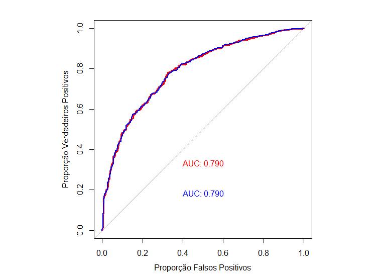

Azul: Bootstrap (0.7902) Vermelho: repeatedcv (0.7904)

## Tempo de processamento

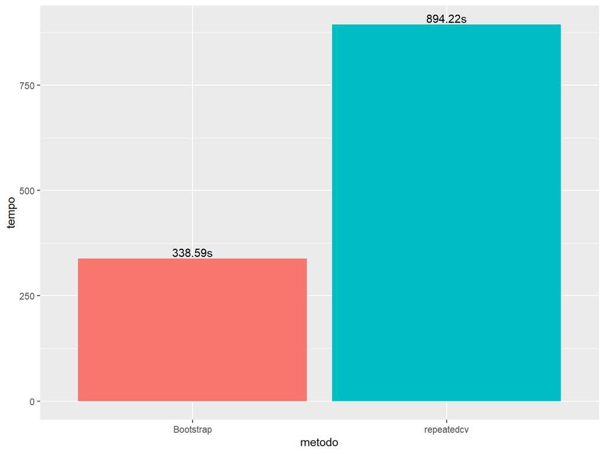

# Modelo escolhido

- O modelo que teve a melhor performance foi o de coeficiente de aprendizado 0.01, profundidade 1 e número de árvores 1000, com reamostragem por kfold repetido.
- Foi realizada a separação conforme a exigência de 25% para amostra teste e 75% para amostra treino. A modelagem a partir da amostra treino obteve o seguinte resultado:

| interaction.depth | n.trees | shrinkage | n.minobsinnode | ROC | Sens | Spec | ROCSD | SensSD | SpecSD |
| --- | --- | --- | --- | --- | --- | --- | --- | --- | --- |
| 1 | 1000 | 0.01 | 10 | 0.7615706 | 0.5305443 | 0.8177931 | 0.044361 | 0.072431 | 0.0497537 |

- Variáveis mais influentes

| Var | Influence |
| --- | --- |
| gp | 45.9172748 |
| fta | 15.6987368 |
| fg | 12.2980805 |
| oreb | 6.6680500 |
| ft | 6.6427327 |
| x3p | 3.9906534 |
| fga | 3.3055565 |
| blk | 2.8876777 |
| ast | 1.1636744 |
| dreb | 0.4858196 |
| tov | 0.3420671 |
| x3pa | 0.3033329 |
| stl | 0.2963437 |

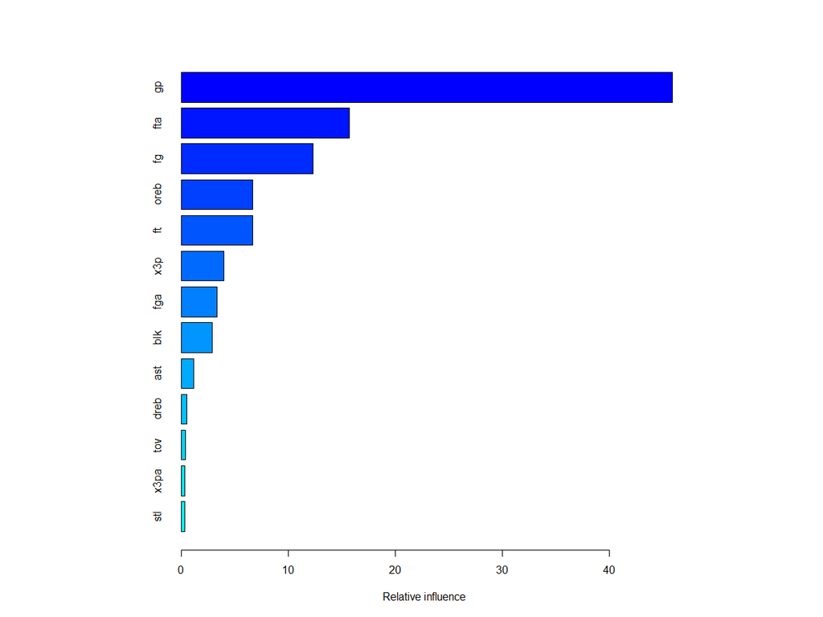

- Aplicando a modelagem na amostra teste, é adquirido um vetor de probabilidades, então assim é necessário adotar um ponto de corte para a classificação.
- Foi utilizado uma função otimizadora que a partir dos dados da predição retorna o melhor ponto de corte, que no caso foi de 0.6033771.

## Curva ROC

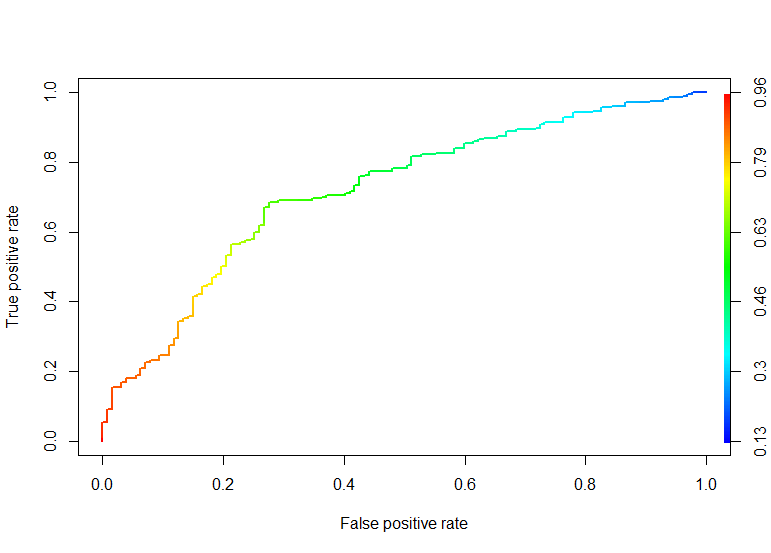

# Resultado Para amostra teste

- Aplicando a modelagem na amostra teste e definindo o ponto de corte, são obtidos os seguintes resultados:

| Acurácia | Sensibilidade | Especificidade | AUC |
| --- | --- | --- | --- |
| 0.7006 | 0.7244 | 0.686 | 0.7178 |

# Conclusão

- Das modelagens feitas, as que mais se destacaram foram aquelas realizadas por kfold repetido.
- Apesar do método kfold ser mais demorado, ele foi escolhido por possuir maiores AUCS em várias modelagens comparados aos de bootstrap.
- O modelo final apresentou Acurácia em torno de 70%, isso significa que o modelo possui uma boa taxa de acerto.
- O modelo apresentou Sensibilidade um pouco maior que a Especificidade, isso mostra que ele acerta mais os verdadeiros positivos do que os verdadeiros negativos.